# **Homework 3**

Create a copy of the notebook to start answering the questions. Name your notebook in the format HW3_lastname_firstname.ipynb to facilitate the grading process.

Answer all the questions, test your code to ensure there are no errors and the results are as expected. Once you have answered all the questions, save the final copy, then go to File-> click on Download.ipynb. Once the local copy has been downloaded, submit your file on Blackboard under the corresponding assignment section. Also provide us a link to your notebook during submission.

The due date of this homework is 02/19/2021 (Friday).

Please ensure you follow all the steps mentioned in the homework.

Most questions have sample outputs to help you understand the question.

You can submit your solutions any number of times until the deadline.

The datasets used in this homework can be found in the google drive link below -

https://drive.google.com/drive/folders/1NxCh4X7u7wVo5aHojxjLNs9wC7B7zJhb?usp=sharing

Follow the necessary steps to import data to test your code. You can use any method to read your data in the notebook. We will not be grading the methods you use. We will only grade the code from the point where you read the dataset into a pandas dataframe - (pd.read_csv('file_name'))

```python
import numpy as np
import pandas as pd
```

# **Problem 1**

mtcars.csv – Dataset extracted from the 1974 Motor Trend US magazine comprising fuel consumption and 10 aspects (attributes) of automobile design and performance for 32 automobiles is a famous problem dataset used in machine learning and data analysis. We will use this dataset to perform data abstraction, slicing, dicing and basic analysis using Pandas Series and DataFrame, as taught in the class.

One of the main purpose of this data was to assist decision making on which car to purchase during the 1973 Oil Crisis which began in October 1973, when the members of the Organization of Arab Petroleum Exporting Countries proclaimed an oil embargo and the affected countries were Canada Japan, Netherlands, United Kingdom and United States and later extended to Portugal, Rhodesia and South Africa. By the end of the embargo in March 1974, the oil price had risen nearly 400%, from \$3 per barrel to nearly \$12 globally; US prices were significantly higher. The embargo caused an oil crisis, or "shock", with many short and long-term effects on global politics and the global economy. It was famously called the “First Oil Shock”.

### 1. We will perform data analysis using Pandas to determine the best car to buy based on the tasks given below.

1.a Read the csv file using Pandas. Store the output into a dataframe named *frame*. Print the dataframe.

```python
# Type solution here
a=pd.read_csv('mtcars.csv')
frame=pd.DataFrame(a)
print(frame)
```

```
               Car Name   mpg  cyl   disp   hp  ...   qsec  vs  am  gear  carb
0             Mazda RX4  21.0    6  160.0  110  ...  16.46   0   1     4     4
1         Mazda RX4 Wag  21.0    6  160.0  110  ...  17.02   0   1     4     4
2            Datsun 710  22.8    4  108.0   93  ...  18.61   1   1     4     1
3        Hornet 4 Drive  21.4    6  258.0  110  ...  19.44   1   0     3     1
4     Hornet Sportabout  18.7    8  360.0  175  ...  17.02   0   0     3     2
5               Valiant  18.1    6  225.0  105  ...  20.22   1   0     3     1
6            Duster 360  14.3    8  360.0  245  ...  15.84   0   0     3     4
7             Merc 240D  24.4    4  146.7   62  ...  20.00   1   0     4     2
8              Merc 230  22.8    4  140.8   95  ...  22.90   1   0     4     2
9              Merc 280  19.2    6  167.6  123  ...  18.30   1   0     4     4
10            Merc 280C  17.8    6  167.6  123  ...  18.90   1   0     4     4
11           Merc 450SE  16.4    8  275.8  180  ...  17.40   0   0     3     3
12           Merc 450SL  17.3    8  275.8  180  ...  17.60   0   0     3     3
13          Merc 450SLC  15.2    8  275.8  180  ...  18.00   0   0     3     3
```

[output cut: 20 more lines]

```python
from google.colab import drive
drive.mount('/content/drive')
```

1.b You notice that the index is 0..31. However, notice that there is a column called Car Name. Set the index of the dataframe to Car Name. In other words, make the column Car Name the index of frame. Print the dataframe after this.

Sample output is shown in the image below.

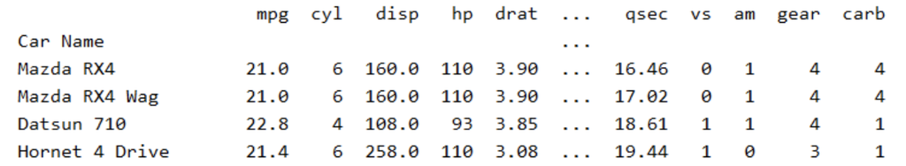

```python
a=pd.read_csv('mtcars.csv',index_col=0)
frame=pd.DataFrame(a)
print(frame)
```

```
                      mpg  cyl   disp   hp  drat  ...   qsec  vs  am  gear  carb
Car Name                                          ...
Mazda RX4            21.0    6  160.0  110  3.90  ...  16.46   0   1     4     4
Mazda RX4 Wag        21.0    6  160.0  110  3.90  ...  17.02   0   1     4     4
Datsun 710           22.8    4  108.0   93  3.85  ...  18.61   1   1     4     1
Hornet 4 Drive       21.4    6  258.0  110  3.08  ...  19.44   1   0     3     1
Hornet Sportabout    18.7    8  360.0  175  3.15  ...  17.02   0   0     3     2
Valiant              18.1    6  225.0  105  2.76  ...  20.22   1   0     3     1
Duster 360           14.3    8  360.0  245  3.21  ...  15.84   0   0     3     4
Merc 240D            24.4    4  146.7   62  3.69  ...  20.00   1   0     4     2
Merc 230             22.8    4  140.8   95  3.92  ...  22.90   1   0     4     2
Merc 280             19.2    6  167.6  123  3.92  ...  18.30   1   0     4     4
Merc 280C            17.8    6  167.6  123  3.92  ...  18.90   1   0     4     4
Merc 450SE           16.4    8  275.8  180  3.07  ...  17.40   0   0     3     3
Merc 450SL           17.3    8  275.8  180  3.07  ...  17.60   0   0     3     3
Merc 450SLC          15.2    8  275.8  180  3.07  ...  18.00   0   0     3     3
Cadillac Fleetwood   10.4    8  472.0  205  2.93  ...  17.98   0   0     3     4
Lincoln Continental  10.4    8  460.0  215  3.00  ...  17.82   0   0     3     4
Chrysler Imperial    14.7    8  440.0  230  3.23  ...  17.42   0   0     3     4
Fiat 128             32.4    4   78.7   66  4.08  ...  19.47   1   1     4     1
Honda Civic          30.4    4   75.7   52  4.93  ...  18.52   1   1     4     2
Toyota Corolla       33.9    4   71.1   65  4.22  ...  19.90   1   1     4     1
Toyota Corona        21.5    4  120.1   97  3.70  ...  20.01   1   0     3     1
Dodge Challenger     15.5    8  318.0  150  2.76  ...  16.87   0   0     3     2
AMC Javelin          15.2    8  304.0  150  3.15  ...  17.30   0   0     3     2
Camaro Z28           13.3    8  350.0  245  3.73  ...  15.41   0   0     3     4
Pontiac Firebird     19.2    8  400.0  175  3.08  ...  17.05   0   0     3     2
Fiat X1-9            27.3    4   79.0   66  4.08  ...  18.90   1   1     4     1
Porsche 914-2        26.0    4  120.3   91  4.43  ...  16.70   0   1     5     2
Lotus Europa         30.4    4   95.1  113  3.77  ...  16.90   1   1     5     2
Ford Pantera L       15.8    8  351.0  264  4.22  ...  14.50   0   1     5     4
Ferrari Dino         19.7    6  145.0  175  3.62  ...  15.50   0   1     5     6
Maserati Bora        15.0    8  301.0  335  3.54  ...  14.60   0   1     5     8
Volvo 142E           21.4    4  121.0  109  4.11  ...  18.60   1   1     4     2

[32 rows x 11 columns]
```

1.c Create a DataFrame using the attributes: 'cyl', 'gear', 'hp', 'mpg'. Ensure that Car Name is the index. Also rename the columns to : Cylinders, Gear, Horsepower, Miles Per Gallon. Print the dataframe.

Sample output is shown below.

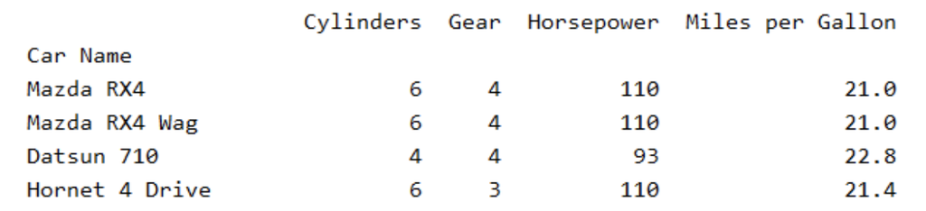

```python
# Type solution here
b=frame.loc[:,['cyl', 'gear', 'hp', 'mpg']]
b1=pd.DataFrame(b)
print(b1)
b2=b1.rename(columns={'cyl':'Cylinders','gear':'Gear','hp':'Horsepower','mpg':'Miles per Gallon'})
print(b2)
```

```
                     cyl  gear   hp   mpg
Car Name
Mazda RX4              6     4  110  21.0
Mazda RX4 Wag          6     4  110  21.0
Datsun 710             4     4   93  22.8
Hornet 4 Drive         6     3  110  21.4
Hornet Sportabout      8     3  175  18.7
Valiant                6     3  105  18.1
Duster 360             8     3  245  14.3
Merc 240D              4     4   62  24.4
Merc 230               4     4   95  22.8
Merc 280               6     4  123  19.2
Merc 280C              6     4  123  17.8
Merc 450SE             8     3  180  16.4
Merc 450SL             8     3  180  17.3
Merc 450SLC            8     3  180  15.2
Cadillac Fleetwood     8     3  205  10.4
Lincoln Continental    8     3  215  10.4
Chrysler Imperial      8     3  230  14.7
Fiat 128               4     4   66  32.4
Honda Civic            4     4   52  30.4
Toyota Corolla         4     4   65  33.9
Toyota Corona          4     3   97  21.5
Dodge Challenger       8     3  150  15.5
AMC Javelin            8     3  150  15.2
Camaro Z28             8     3  245  13.3
Pontiac Firebird       8     3  175  19.2
Fiat X1-9              4     4   66  27.3
Porsche 914-2          4     5   91  26.0
Lotus Europa           4     5  113  30.4
Ford Pantera L         8     5  264  15.8
Ferrari Dino           6     5  175  19.7
Maserati Bora          8     5  335  15.0
Volvo 142E             4     4  109  21.4
                     Cylinders  Gear  Horsepower  Miles per Gallon
Car Name
Mazda RX4                    6     4         110              21.0
Mazda RX4 Wag                6     4         110              21.0
Datsun 710                   4     4          93              22.8
Hornet 4 Drive               6     3         110              21.4
```

[output cut: 13 more lines]

```
Fiat 128                     4     4          66              32.4
Honda Civic                  4     4          52              30.4
Toyota Corolla               4     4          65              33.9
Toyota Corona                4     3          97              21.5
Dodge Challenger             8     3         150              15.5
AMC Javelin                  8     3         150              15.2
Camaro Z28                   8     3         245              13.3
Pontiac Firebird             8     3         175              19.2
Fiat X1-9                    4     4          66              27.3
Porsche 914-2                4     5          91              26.0
Lotus Europa                 4     5         113              30.4
Ford Pantera L               8     5         264              15.8
Ferrari Dino                 6     5         175              19.7
Maserati Bora                8     5         335              15.0
Volvo 142E                   4     4         109              21.4
```

1.d Now, identify cars with ‘Horsepower’ greater than or equal to 110, and add a separate column called ‘Powerful’ to the DataFrame which holds the result of cars with ‘Horsepower’ greater than or equal to 110. Print the dataframe.

Sample output is shown below.

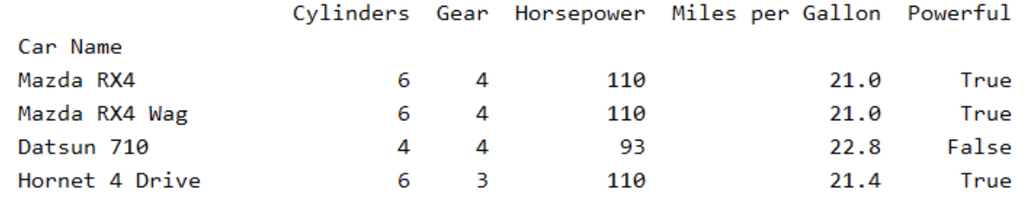

```python
# Type solution here
Powerful=b2.Horsepower>=110
b2['Powerful']= Powerful
print(b2)
```

```
                     Cylinders  Gear  Horsepower  Miles per Gallon  Powerful
Car Name
Mazda RX4                    6     4         110              21.0      True
Mazda RX4 Wag                6     4         110              21.0      True
Datsun 710                   4     4          93              22.8     False
Hornet 4 Drive               6     3         110              21.4      True
Hornet Sportabout            8     3         175              18.7      True
Valiant                      6     3         105              18.1     False
Duster 360                   8     3         245              14.3      True
Merc 240D                    4     4          62              24.4     False
Merc 230                     4     4          95              22.8     False
Merc 280                     6     4         123              19.2      True
Merc 280C                    6     4         123              17.8      True
Merc 450SE                   8     3         180              16.4      True
Merc 450SL                   8     3         180              17.3      True
Merc 450SLC                  8     3         180              15.2      True
Cadillac Fleetwood           8     3         205              10.4      True
Lincoln Continental          8     3         215              10.4      True
Chrysler Imperial            8     3         230              14.7      True
Fiat 128                     4     4          66              32.4     False
Honda Civic                  4     4          52              30.4     False
Toyota Corolla               4     4          65              33.9     False
Toyota Corona                4     3          97              21.5     False
Dodge Challenger             8     3         150              15.5      True
AMC Javelin                  8     3         150              15.2      True
Camaro Z28                   8     3         245              13.3      True
Pontiac Firebird             8     3         175              19.2      True
Fiat X1-9                    4     4          66              27.3     False
Porsche 914-2                4     5          91              26.0     False
Lotus Europa                 4     5         113              30.4      True
Ford Pantera L               8     5         264              15.8      True
Ferrari Dino                 6     5         175              19.7      True
Maserati Bora                8     5         335              15.0      True
Volvo 142E                   4     4         109              21.4     False
```

1.e Store the dataframe in another variable/ keep a copy of the dataframe. Now print the new DataFrame with the column ‘Horse Power’ deleted.

Sample output is shown below.

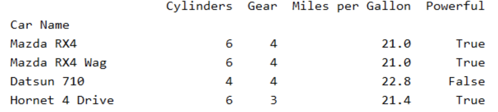

```python
# Type solution here
b3=pd.DataFrame(b2.drop(columns='Horsepower'))
print(b3)
```

```
                     Cylinders  Gear  Miles per Gallon  Powerful
Car Name
Mazda RX4                    6     4              21.0      True
Mazda RX4 Wag                6     4              21.0      True
Datsun 710                   4     4              22.8     False
Hornet 4 Drive               6     3              21.4      True
Hornet Sportabout            8     3              18.7      True
Valiant                      6     3              18.1     False
Duster 360                   8     3              14.3      True
Merc 240D                    4     4              24.4     False
Merc 230                     4     4              22.8     False
Merc 280                     6     4              19.2      True
Merc 280C                    6     4              17.8      True
Merc 450SE                   8     3              16.4      True
Merc 450SL                   8     3              17.3      True
Merc 450SLC                  8     3              15.2      True
Cadillac Fleetwood           8     3              10.4      True
Lincoln Continental          8     3              10.4      True
Chrysler Imperial            8     3              14.7      True
Fiat 128                     4     4              32.4     False
Honda Civic                  4     4              30.4     False
Toyota Corolla               4     4              33.9     False
Toyota Corona                4     3              21.5     False
Dodge Challenger             8     3              15.5      True
AMC Javelin                  8     3              15.2      True
Camaro Z28                   8     3              13.3      True
Pontiac Firebird             8     3              19.2      True
Fiat X1-9                    4     4              27.3     False
Porsche 914-2                4     5              26.0     False
Lotus Europa                 4     5              30.4      True
Ford Pantera L               8     5              15.8      True
Ferrari Dino                 6     5              19.7      True
Maserati Bora                8     5              15.0      True
Volvo 142E                   4     4              21.4     False
```

1.f Using the original DataFrame (with 'Horsepower' column), list cars with 'Miles Per Gallon' greater than 25.0 and sort the cars in descending order of 'Horsepower'

Sample output is shown below.

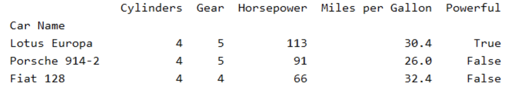

```python
# Type solution here
b4=pd.DataFrame(b2[b2['Miles per Gallon']>25])
print(b4)
b5=b4.sort_values(by=['Horsepower'],ascending=False)
print(b5)
```

```
                Cylinders  Gear  Horsepower  Miles per Gallon  Powerful
Car Name
Fiat 128                4     4          66              32.4     False
Honda Civic             4     4          52              30.4     False
Toyota Corolla          4     4          65              33.9     False
Fiat X1-9               4     4          66              27.3     False
Porsche 914-2           4     5          91              26.0     False
Lotus Europa            4     5         113              30.4      True
                Cylinders  Gear  Horsepower  Miles per Gallon  Powerful
Car Name
Lotus Europa            4     5         113              30.4      True
Porsche 914-2           4     5          91              26.0     False
Fiat 128                4     4          66              32.4     False
Fiat X1-9               4     4          66              27.3     False
Toyota Corolla          4     4          65              33.9     False
Honda Civic             4     4          52              30.4     False
```

1.g Filter out the car that is powerful and has the highest Miles Per Gallon.

Output is shown below.

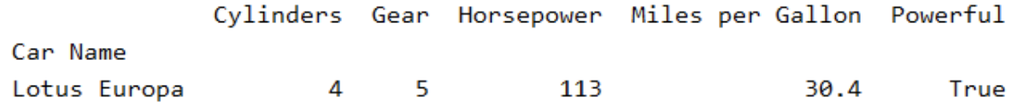

```python
# Type solution here

b6=b2[(b2['Powerful']==True)]
b7=pd.DataFrame(b6)
b8=pd.DataFrame(b7.sort_values(by='Miles per Gallon',ascending=False)).head(1)
print(b8)
```

[output not shown]

# **Problem 2**

The avocado.csv dataset contains price and quantity of avocados sold over time in various regions.

Additionally –

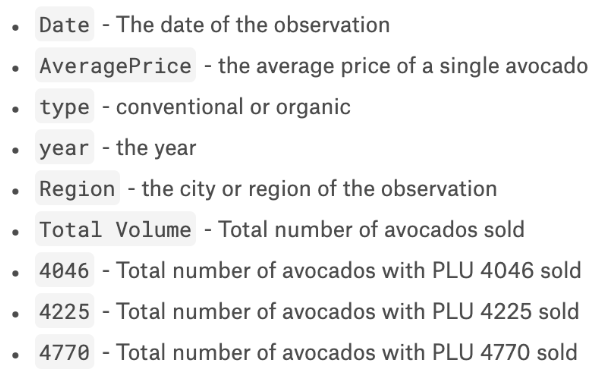

### 1. Preparation

1.a Read the dataset into Python using Pandas. Include only these columns: Date, AveragePrice, Total Volume. Store the data in a DataFrame named *avocado* and print the dataframe.

```python
# Type solution here
avocado = pd.read_csv('avocado.csv', index_col='Date', usecols=['Date', 'AveragePrice', 'Total Volume'])
print(avocado)
```

```
            AveragePrice  Total Volume
Date
12/27/2015          1.33      64236.62
12/20/2015          1.35      54876.98
12/13/2015          0.93     118220.22
12/6/2015           1.08      78992.15
11/29/2015          1.28      51039.60
...                  ...           ...
2/4/2018            1.63      17074.83
1/28/2018           1.71      13888.04
1/21/2018           1.87      13766.76
1/14/2018           1.93      16205.22
1/7/2018            1.62      17489.58

[18249 rows x 2 columns]
```

1.b Convert Date column to a timestamp using datetime. Print the dataframe.

```python
# Type solution here
avocado.index = pd.to_datetime(avocado.index)
print(avocado)
```

```
            AveragePrice  Total Volume
Date
2015-12-27          1.33      64236.62
2015-12-20          1.35      54876.98
2015-12-13          0.93     118220.22
2015-12-06          1.08      78992.15
2015-11-29          1.28      51039.60
...                  ...           ...
2018-02-04          1.63      17074.83
2018-01-28          1.71      13888.04
2018-01-21          1.87      13766.76
2018-01-14          1.93      16205.22
2018-01-07          1.62      17489.58

[18249 rows x 2 columns]
```

### 2. Plotting

Your final output after following the below steps should appear as below -

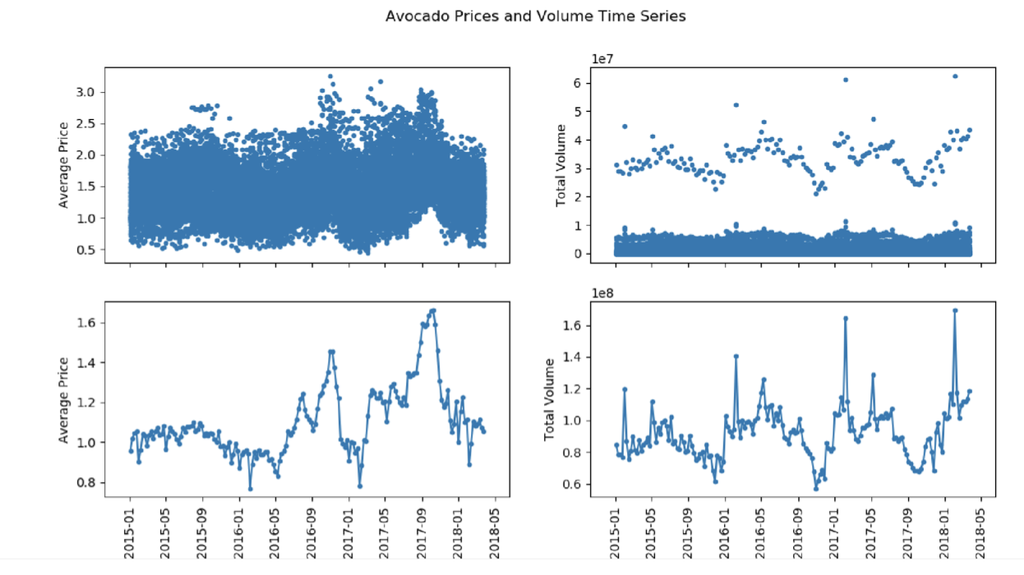

2.a Create a figure with 4 subplots.

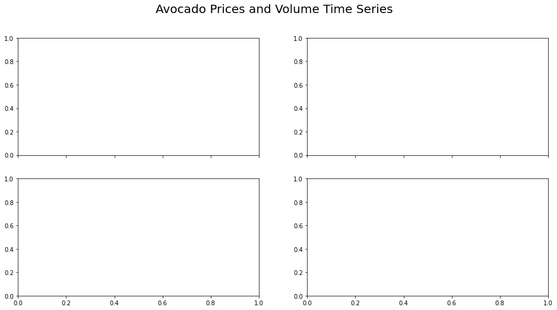

```python
# Type solution here
import matplotlib.pyplot as plt

myFig, myAxes = plt.subplots(2, 2, figsize=(16, 8), sharey=False, sharex=True)
myFig.suptitle('Avocado Prices and Volume Time Series', fontsize=20)
plt.show()
```

2.b Sort avocado by Date inplace in ascending order.

```python
# Type solution here
avocado.sort_index(ascending=True, inplace=True)
print(avocado)
```

```
            AveragePrice  Total Volume
Date
2015-01-04          1.75      27365.89
2015-01-04          1.49      17723.17
2015-01-04          1.68       2896.72
2015-01-04          1.52      54956.80
2015-01-04          1.64       1505.12
...                  ...           ...
2018-03-25          1.36     908202.13
2018-03-25          0.70    9010588.32
2018-03-25          1.42     163496.70
2018-03-25          1.70     190257.38
2018-03-25          1.34    1774776.77

[18249 rows x 2 columns]
```

2.c Plot the average price of avocados over time in subplot 1. Use *scatter()*.

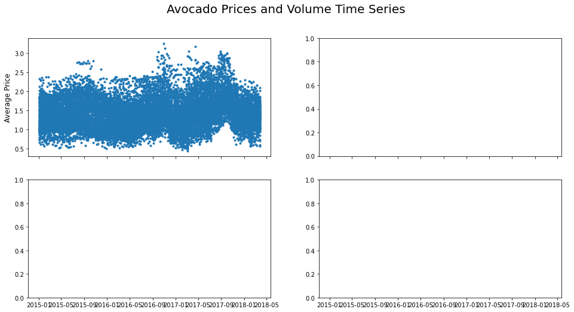

```python
# Type solution here

# Date, AveragePrice, TotalVolume = avocado['Date'], avocado['AveragePrice'], avocado['Total Volume']

myFig, myAxes = plt.subplots(2, 2, figsize=(16, 8), sharey=False, sharex=True)
myFig.suptitle('Avocado Prices and Volume Time Series', fontsize=20)

myAxes[0, 0].scatter(avocado.index, avocado.AveragePrice, marker ='.')
myAxes[0, 0].set_ylabel('Average Price', fontsize=12)
plt.show()
```

2.d Plot the total volume of avocados sold over time in subplot 2. Use *scatter()*.

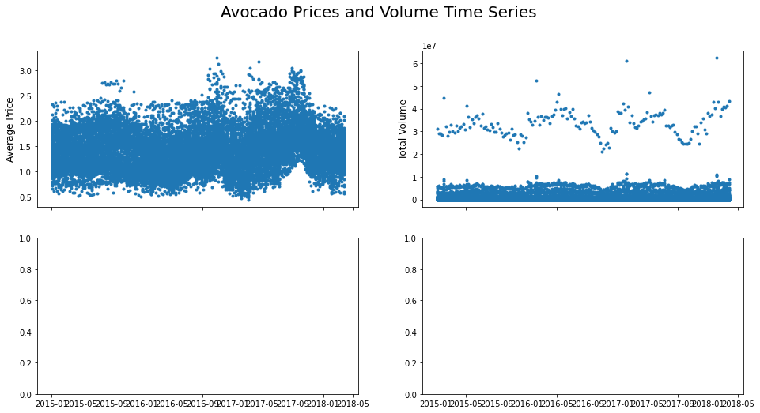

```python
# Type solution here
myFig, myAxes = plt.subplots(2, 2, figsize=(16, 8), sharey=False, sharex=True)
myFig.suptitle('Avocado Prices and Volume Time Series', fontsize=20)

myAxes[0, 0].scatter(avocado.index, avocado.AveragePrice, marker ='.')
myAxes[0, 0].set_ylabel('Average Price', fontsize=12)

myAxes[0, 1].scatter(avocado.index, avocado['Total Volume'], marker='.')
myAxes[0, 1].set_ylabel('Total Volume', fontsize=12)
plt.show()
```

2.e You notice that the plots are cluttered. The reason is that there are many dates in the dataframe and there are several transactions on the same date!

To address this, we will aggregate the volume and price by date.

Create a new dataframe *avocado1* which sums the Total Volume for each date.

Here are the steps -

- Create a new column in avocado called TotalRevenue which is the product of average price and total volume.
- Then create a new dataframe called avocado1 which groups together the dataframe over the date

  **avocado1 = avocado.groupby('Date').sum()**
- Print *avocado1*. You will notice that the AveragePrice also got aggregated. This is not correct.
- Recalculate the average price using this

  **avocado1['AveragePrice'] = avocado1['TotalRevenue']/avocado1['Total Volume']**
- You should now have the following dataframe. Print the dataframe.

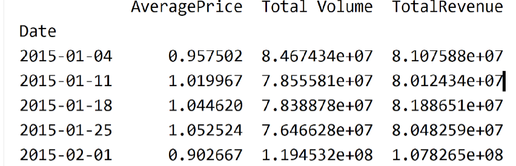

```python
# Type solution here
# TotalRevenue=avocado.AveragePrice * avocado['Total Volume']
avocado['TotalRevenue']=avocado['AveragePrice'] * avocado['Total Volume']
print(avocado)

avocado1 = avocado.groupby('Date').sum()
avocado1['AveragePrice'] = avocado1['TotalRevenue'] / avocado1['Total Volume']
print(avocado1)
```

```
            AveragePrice  Total Volume  TotalRevenue
Date
2015-01-04          1.75      27365.89  4.789031e+04
2015-01-04          1.49      17723.17  2.640752e+04
2015-01-04          1.68       2896.72  4.866490e+03
2015-01-04          1.52      54956.80  8.353434e+04
2015-01-04          1.64       1505.12  2.468397e+03
...                  ...           ...           ...
2018-03-25          1.36     908202.13  1.235155e+06
2018-03-25          0.70    9010588.32  6.307412e+06
2018-03-25          1.42     163496.70  2.321653e+05
2018-03-25          1.70     190257.38  3.234375e+05
2018-03-25          1.34    1774776.77  2.378201e+06

[18249 rows x 3 columns]
            AveragePrice  Total Volume  TotalRevenue
Date
2015-01-04      0.957502  8.467434e+07  8.107588e+07
2015-01-11      1.019967  7.855581e+07  8.012434e+07
2015-01-18      1.044620  7.838878e+07  8.188651e+07
2015-01-25      1.052524  7.646628e+07  8.048259e+07
2015-02-01      0.902667  1.194532e+08  1.078265e+08
...                  ...           ...           ...
2018-02-25      1.082475  1.092314e+08  1.182403e+08
2018-03-04      1.090295  1.118449e+08  1.219440e+08
2018-03-11      1.110900  1.114652e+08  1.238267e+08
2018-03-18      1.072436  1.136740e+08  1.219081e+08
2018-03-25      1.055488  1.182690e+08  1.248315e+08

[169 rows x 3 columns]
```

2.f Plot the average price of avocado1 over time in subplot 3. Use *plot()*.

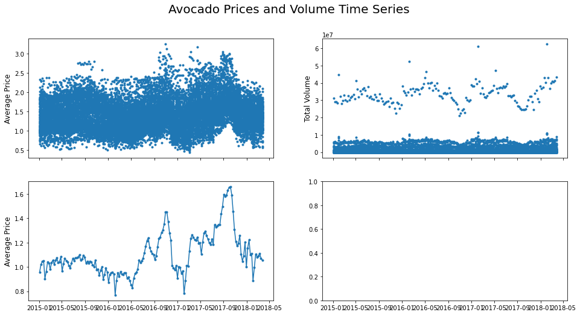

```python
# Type solution here
myFig, myAxes = plt.subplots(2, 2, figsize=(16, 8), sharey=False, sharex=True)
myFig.suptitle('Avocado Prices and Volume Time Series', fontsize=20)

myAxes[0, 0].scatter(avocado.index, avocado.AveragePrice, marker ='.')
myAxes[0, 0].set_ylabel('Average Price', fontsize=12)

myAxes[0, 1].scatter(avocado.index, avocado['Total Volume'], marker='.')
myAxes[0, 1].set_ylabel('Total Volume', fontsize=12)

myAxes[1, 0].plot(avocado1.index, avocado1.AveragePrice, '.-')
myAxes[1, 0].set_ylabel('Average Price', fontsize=12)
plt.show()
```

2.g Plot the total volume of avocado1 sold over time in subplot 4. Use *plot()*.

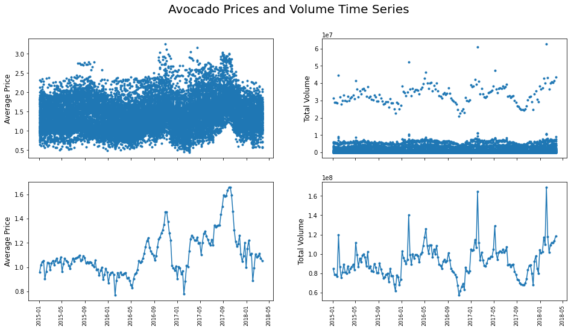

```python
# Type solution here
myFig, myAxes = plt.subplots(2, 2, figsize=(16, 8), sharey=False, sharex=True)
myFig.suptitle('Avocado Prices and Volume Time Series', fontsize=20)

myAxes[0, 0].scatter(avocado.index, avocado.AveragePrice, marker ='.')
myAxes[0, 0].set_ylabel('Average Price', fontsize=12)

myAxes[0, 1].scatter(avocado.index, avocado['Total Volume'], marker='.')
myAxes[0, 1].set_ylabel('Total Volume', fontsize=12)

myAxes[1, 0].plot(avocado1.index, avocado1.AveragePrice, '.-')
myAxes[1, 0].set_ylabel('Average Price', fontsize=12)

myAxes[1, 1].plot(avocado1.index, avocado1['Total Volume'], '.-')
myAxes[1, 1].set_ylabel('Total Volume', fontsize=12)

myAxes[1, 0].set_xticklabels(['2015-01', '2015-05', '2015-09', '2016-01', '2016-05', '2016-09','2017-01','2017-05','2017-09','2018-01','2018-05'], rotation=90, fontsize='small') # xtick labels
myAxes[1, 1].set_xticklabels(['2015-01', '2015-05', '2015-09', '2016-01', '2016-05', '2016-09','2017-01','2017-05','2017-09','2018-01','2018-05'], rotation=90, fontsize='small')
plt.show()
```

### 3. Plotting

Your final output after following the below steps should appear as below -

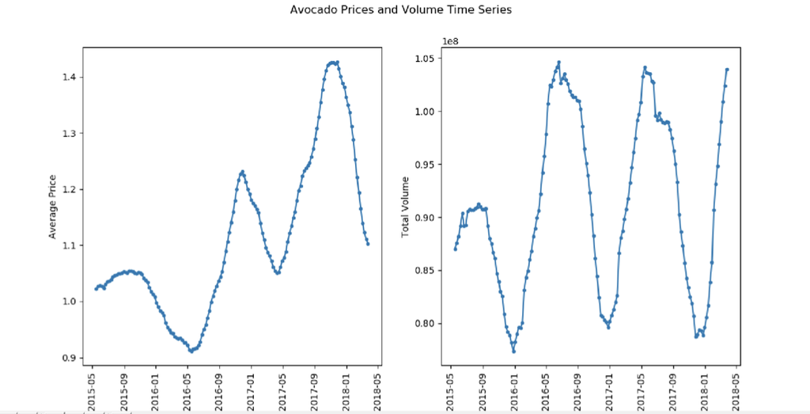

3.a Create a figure with 2 subplots

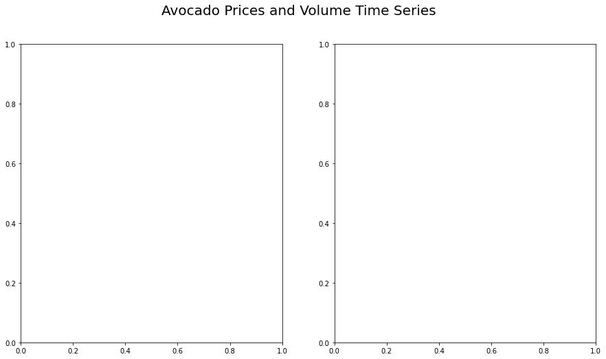

```python
# Type solution here
myFig, myAxes = plt.subplots(1,2, figsize=(15, 8), sharey=False, sharex=False)
myFig.suptitle('Avocado Prices and Volume Time Series', fontsize=20)
```

```
# Rolling with a window of 12 observations. We then consider mean of those 12 observations.

result = df['Column_Name'].rolling(12).mean()
```

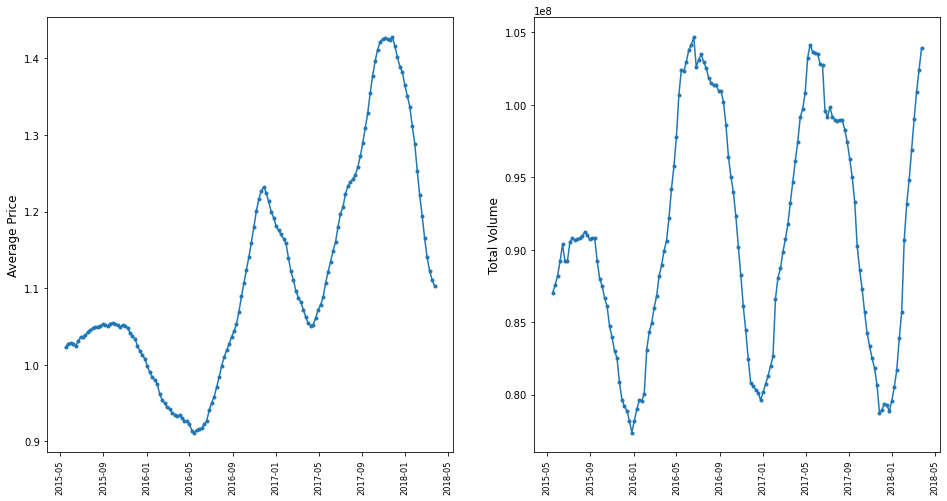

```python
# Type solution here
myFig, myAxes = plt.subplots(1,2, figsize=(16, 8), sharey=False, sharex=False)

SmoothAveragePrice = avocado1['AveragePrice'].rolling(20).mean()
SmoothTotalVolume = avocado1['Total Volume'].rolling(20).mean()

myAxes[0].plot(avocado1.index, SmoothAveragePrice, '.-')
myAxes[0].set_ylabel('Average Price', fontsize=12)

myAxes[1].plot(avocado1.index, SmoothTotalVolume, '.-')
myAxes[1].set_ylabel('Total Volume', fontsize=12)

myAxes[0].set_xticklabels(['2015-05', '2015-09', '2016-01', '2016-05', '2016-09','2017-01','2017-05','2017-09','2018-01','2018-05'], rotation=90, fontsize='small') # xtick labels
myAxes[1].set_xticklabels(['2015-05', '2015-09', '2016-01', '2016-05', '2016-09','2017-01','2017-05','2017-09','2018-01','2018-05'], rotation=90, fontsize='small')
plt.show()
```